# VL01: Einstieg Problemlösen

IFM 5.6 Künstliche Intelligenz, 2017/18

Carsten Gips, FH Bielefeld

# Motivation

## Probleme

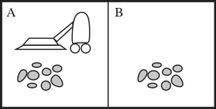

Quelle: [AIMA 3rd ed.](http://aima.cs.berkeley.edu)

## Themen für heute

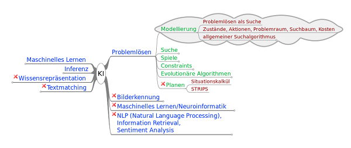

Am Ende der VL können/verstehen Sie:

- Welche Bereiche der KI gibt es
- Wie kann ein Problem formalisiert werden

# Was ist Künstliche Intelligenz?

## Was ist (künstliche) Intelligenz?

[figure not shown]

Quelle: [wikipedia.de](http://upload.wikimedia.org/wikipedia/en/0/09/DataTNG.jpg)

- Ist Cmdr. Data intelligent?
- Woran erkennen Sie das?

Diskussion

## Definition Intelligenz

de.wikipedia.org/wiki/Intelligenz (06.10.2017)

> Intelligenz (von lat. *intellegere* “verstehen”, wörtlich “wählen zwischen …” von lat. *inter* “zwischen” und *legere* “lesen, wählen”) ist in der Psychologie ein Sammelbegriff für die **kognitive Leistungsfähigkeit** des Menschen. Da einzelne kognitive Fähigkeiten unterschiedlich stark ausgeprägt sein können und keine Einigkeit besteht, wie diese zu bestimmen und zu unterscheiden sind, gibt es **keine allgemeingültige Definition der Intelligenz**.

> Mit Intelligenz befassen sich die allgemeine und die differentielle Psychologie sowie die Neuropsychologie. Die Erforschung der Intelligenz auf dem Gebiet der allgemeinen Psychologie bezeichnet man heute oft als kognitive Psychologie. Diese wiederum greift auf Methoden und Erkenntnisse der Hirnforschung, der Entwicklungspsychologie und zunehmend auch der **künstlichen Intelligenz** zurück.

de.wikipedia.org/wiki/Kognition (06.10.2017)

> Kognition ist ein uneinheitlich verwendeter Begriff, mit dem auf die Informationsverarbeitung von Menschen und anderen Systemen Bezug genommen wird. Oft ist mit “Kognition” das Denken in einem umfassenden Sinne gemeint.

> Zu den **kognitiven Fähigkeiten** eines Menschen zählen die **Wahrnehmung**, die Aufmerksamkeit, die Erinnerung, das **Lernen**, das **Problemlösen**, die Kreativität, das **Planen**, die Orientierung, die Imagination, die **Argumentation**, die Introspektion, der Wille, das Glauben und einige mehr. Auch Emotionen haben einen wesentlichen kognitiven Anteil.

> Kognitive Fähigkeiten werden von verschiedenen Wissenschaften untersucht, z.B. der Psychologie, der Biologie, den Neurowissenschaften, der Psychiatrie, der Philosophie und der Forschung zur Künstlichen-Intelligenz. Die wissenschaftliche Erforschung der Kognition wird unter dem Begriff der Kognitionswissenschaft zusammengefasst.

## Versuch einer Definition für “KI”

> Ziel der KI ist es, Maschinen zu entwickeln, die sich verhalten, als verfügten sie über Intelligenz.

> – John McCarthy (1955)

Einwand: Braitenberg-Vehikel zeigen so etwas wie “intelligentes” Verhalten, sind aber noch lange nicht intelligent! Bezieht sich nur auf *Verhalten*!

> KI ist die Fähigkeit digitaler Computer oder computergesteuerter Roboter, Aufgaben zu lösen, die normalerweise mit den höheren intellektuellen Verarbeitungsfähigkeiten von Menschen in Verbindung gebracht werden …

> – Encyclopedia Britannica

Einwand: Dann wäre aber auch Auswendig-Lernen oder das Multiplizieren langer Zahlen als intelligent zu betrachten! Bezieht sich vor allem auf “*Denken*”!

> Artificial Intelligence is the study of how to make computers do things at which, at the moment, people are better.

> – Elaine Rich (“Artificial Intelligence”, McGraw-Hill, 1983)

Dazu gehört auch

- Anpassung an sich verändernde Situationen
- Erkennung von Bildern und Gesichtern und Emotionen
- Erkennung von Sprache
- Umgang mit kontextbehafteten, unvollständigen Informationen
- Ausräumen von Geschirrspülern ;-)
- Über Emotionen und Empathie verfügen

## Typische Ansätze in der KI

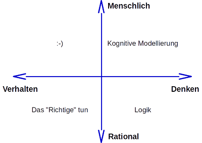

Untersuchung von

- Verhalten vs. Denken
- Rational vs. menschlich

Motivation dabei

- Menschliche Intelligenz verstehen
- Intelligente/intelligent wirkende Systeme bauen

=> Damit erhält man vier Kombinationen:

- Menschliches Denken
- Rationales Denken
- Rationales Verhalten
- Menschliches Verhalten

### Menschliches Denken: Kognitive Modellierung

- Welche kognitiven Fähigkeiten sind für intelligentes Verhalten nötig? Wie laufen Denkprozesse im Gehirn ab?
- Erfordert Theorien über interne Aktivitäten des Gehirns
- Ansätze:
  - top-down: Vorhersage und Test von menschlichem Verhalten
  - bottom-up: Auswertung neurobiologischer Daten
- Wissenschaftszweige: Kognitionswissenschaft (Verbindung der Computermodelle der KI mit den Experimenten und Theorien der Psychologie), Neurobiologie/-informatik

### Rationales Denken: Aristoteles: Was sind korrekte Argumente und Denkprozesse? => Wie sollen wir denken?

Beispiel:

```
Fakt: Sokrates ist ein Mensch.
Fakt: Alle Menschen sind sterblich.
Folgerung: Sokrates ist sterblich.
```

- Formalisierte Problembeschreibung
- Problemlösung durch *logische Prozesse*
- Verbindung von moderner KI zur Mathematik und Philosophie

### Rationales Verhalten: Das “Richtige” tun

- Das “Richtige”: Verhalten zum Erzielen des besten (erwarteten) Ergebnisses (unter Berücksichtigung der verfügbaren Informationen)

  Ein System ist rational, wenn es das seinen Kenntnissen nach “Richtige” macht.
- Denken ist nicht unbedingt notwendig (zb. Reflexe können auch rationales Verhalten sein)
- Interessant: “richtige” Handlung unter unvollständigen/unsicheren Informationen

### Menschliches Verhalten: Naja, Sie wissen schon ;-)

## Alan Turing 1950: Turing Test

- Wann verhält sich eine Maschine intelligent?

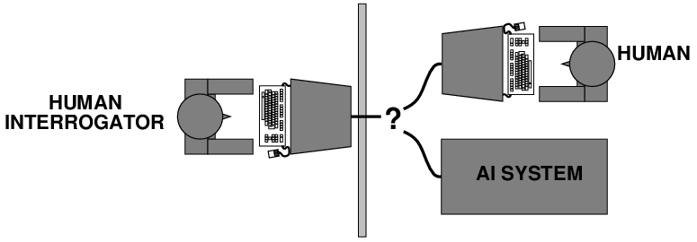

Quelle: [AIMA 3rd ed.](http://aima.cs.berkeley.edu)

**Turing Test begründet Zweige der KI**

Zum Bestehen des Turing-Tests ist (u.a.) erforderlich:

- *Wissensrepräsentation*: Speichern des gesammelten Wissens
- *Logisches Schliessen*: Beantworten von Fragen mit Hilfe des vorhandenen Wissens
- *Maschinelles Lernen*: Anpassung an veränderliches Umfeld
- *Verarbeitung natürlicher Sprache*: Erfolgreiche Kommunikation, beispielsweise in Englisch

“Totaler Turing Test”: zusätzlich *Computer Vision* (Erkennen von Objekten) und *Robotik* (Manipulation von Objekten)

Anmerkung: Der Turing Test ist nicht reproduzierbar, nicht konstruktiv und nicht mathematisch analysierbar …

## Kurzer Geschichtsüberblick

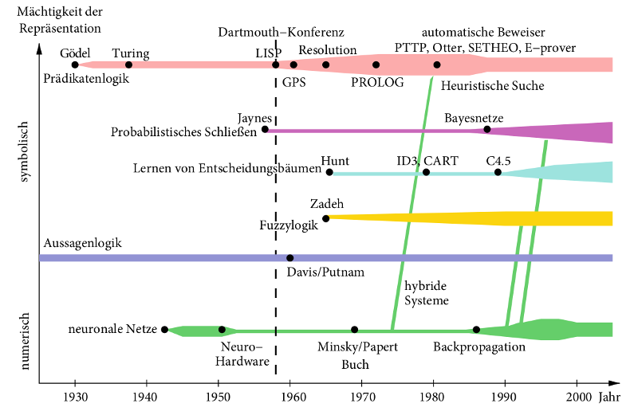

Quelle: Ertelt: “Grundkurs Künstliche Intelligenz”, Springer Vieweg

Wichtigste Meilensteine:

- 1943: McCulloch/Pitts: binäres Modell eines Neurons
- 1950: Turing Test
- 1956: Dartmouth Workshop – McCarthy schlägt den Begriff “Artificial Intelligence” vor
- 1960er: Symbolische KI (Theorembeweiser), Blockwelt, LISP
- 1970er: Wissensbasierte System (Expertensysteme)
- 1980er: zunächst kommerzieller Erfolg der Expertensysteme, später Niedergang (“KI-Eiszeit”); Zuwendung zu Neuronalen Netzen
- 1990er: Formalisierung der KI-Methoden, Einführung probabilistischer Methoden (Bayes’sches Schliessen), verstärkte mathematische Fundierung
- heute: friedliche Koexistenz verschiedener Paradigmen und Methoden; Rückkehr zu “Human-Level AI” (McCarthy, Minsky, Nilsson, Winston); Rückkehr zu Neuronalen Netzen (CNN/RNN, vgl. Google)

# Problemlösen

## Motivation: Staubsauger-Welt

Programmieren Sie einen Staubsauger-Roboter.

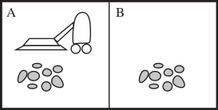

Quelle: [AIMA 3rd ed.](http://aima.cs.berkeley.edu)

**Aktionen:**

- Rechts (R)
- Links (L)
- Saugen (S)

**Wahrnehmungen:**

- Boden verschmutzt?
- In welchem Raum bin ich?

**Aufgabe:** Die Räume säubern.

Hinweis Agent, Umwelt, Modellierung

Bemerkungen zur Umwelt:

- Beobachtbarkeit der Umwelt kann variieren: “voll beobachtbar” bis zu “unbeobachtbar”
- Umwelt kann “deterministisch” oder “stochastisch” sein: Führt eine Aktion in einem Zustand immer zum selben Folgezustand?
- Wann erfolgt die Rückmeldung an den Agenten über die Auswirkung der Aktionen? Sofort (“sequentiell”) oder erst am Ende einer Aktionsfolge (“episodisch”)?
- Wird die Umwelt nur durch die Aktionen des Agenten verändert (“statisch”)? Oder verändert sich die Umwelt zwischen den Aktionen eines Agenten, beispielsweise durch andere Agenten (“dynamisch”)?
- Gibt es diskrete Zustände (wie im Beispiel)?

## Zustandsraum der Staubsauger-Welt

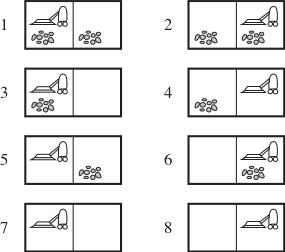

Quelle: [AIMA 3rd ed.](http://aima.cs.berkeley.edu)

**Problem:** Gegeben einen Startzustand, wie komme ich zum Ziel?

- Welche Aktionen können in einem Zustand (zb. Nr. 4) angewendet werden?
- Welche Aktionen können in den Folgezuständen angewendet werden?

Ergebnis:

- Problemgraph (Knoten: Zustände, (gerichtete) Kanten: Aktionen)
- Zustandsraum: Menge aller von den Startzuständen aus erreichbaren Zuständen

Tafel: Skizze Problemgraph

## Suche im Problemgraphen

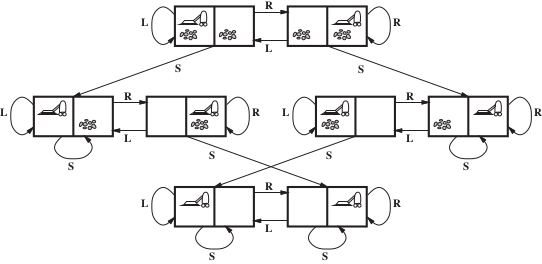

Quelle: [AIMA 3rd ed.](http://aima.cs.berkeley.edu)

Tafel: Skizze Suchbaum, mit und ohne Wdhlg.

- Durch die Suche im Problemgraphen wird der Suchbaum aufgespannt
- Varianten: Zustände können in einem Pfad wiederholt vorkommen vs. Wiederholungen werden ausgeschlossen

## Definition Zustand und Aktion

**Zustand:**

Beschreibung eines Zustandes der Welt

**Aktion:**

Beschreibung einer durch Agenten ausführbaren Aktion

=> Anwendbar auf bestimmte Zustände

=> Überführt Welt in neuen Zustand

Geeignete Abstraktionen wählen für Zustände und Aktionen!

**Anmerkung:** AIMA unterscheidet zw. Aktionen und Transitionsmodell; hier nur Aktionen!

## Definition Problem

Ein Problem besteht aus:

**Startzustände**

Menge $S_A \subset S$

**Aktionen**

Menge von Funktionen $\operatorname{op}: S \to S$

**Zustandsraum**

Menge aller Zustände $S$, die durch (wiederholte) Anwendung von Aktionen von den Startzuständen aus erreichbar sind

**Zieltest**

Funktion $\operatorname{goal}: S \to \{0,1\}$

**Zielzustände**

Menge $S_E \subseteq S$ mit $\forall x \in S_E :\; \operatorname{goal}(x)=1$

**Kosten**

**Gesamtkosten**: $f(n) = g(n) + h(n)$

- $n \in S$ auf dem aktuellen Weg erreichter Knoten
- $g(n)$ tatsächliche Kosten für den Weg vom Start bis zu Knoten $n$
- $h(n)$ geschätzte Restkosten für den Weg von Knoten $n$ zum Ziel

## Unterschied Zustand und Knoten

- Zustände und Aktionen bilden einen Graph (**Problemgraph**)
- Unterscheidung Zustand und Knoten:
  - Zustand: Beschreibung/Modellierung eines Zustandes der Welt
  - Knoten: Datenstruktur, Bestandteil des Graphen, *symbolisiert* einen Zustand

Wird der Einfachheit halber im Sprachgebrauch hier nicht unterschieden, sofern es eindeutig ist, was gemeint ist.

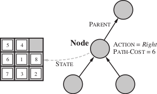

Quelle: [AIMA 3rd ed.](http://aima.cs.berkeley.edu)

## Definition Problemlösen

**Problemlösen**

Wegesuche im Graph vom Startknoten zu einem Zielknoten

=> Spannt den **Suchbaum** auf

**Lösung**

Folge von Aktionen, die Start- in Zielzustand überführen

Ergebnis des Problemlösens

## Suchvarianten: Tree-Search

1. Füge Startknoten in leere Datenstruktur (Stack, Queue, …) ein
2. Entnimm Knoten aus der Datenstruktur:
   1. Knoten ist gesuchtes Element: Abbruch, melde “*gefunden*”
   2. Expandiere alle Nachfolger des Knotens und füge diese in die Datenstruktur ein
3. Falls die Datenstruktur leer ist: Abbruch, melde “*nicht gefunden*”
4. Gehe zu Schritt 2
- Anmerkung: Für Handsimulation besserer Überblick, wenn statt der Knoten immer partielle Wege in Datenstruktur gespeichert werden!

Tafel: Bezug zum Staubsauger-Beispiel

## Suchvarianten: Graph-Search

**Vermeiden von Wiederholungen**

1. Füge Startknoten in leere Datenstruktur (Stack, Queue, …) ein
2. Entnimm Knoten aus der Datenstruktur:
   1. Knoten ist gesuchtes Element: Abbruch, melde “*gefunden*”
   2. Markiere aktuellen Knoten, und
   3. Expandiere alle Nachfolger des Knotens und füge alle unmarkierten Nachfolger, die noch nicht in der Datenstruktur sind, in die Datenstruktur ein
3. Falls die Datenstruktur leer ist: Abbruch, melde “*nicht gefunden*”
4. Gehe zu Schritt 2
- Anmerkung: Für Handsimulation besserer Überblick, wenn statt der Knoten immer **partielle Wege** in Datenstruktur gespeichert werden!

## Bewertung von Suchalgorithmen

**Vollständigkeit**

Findet der Algorithmus eine Lösung, wenn es eine gibt?

**Optimalität**

Findet der Algorithmus die beste Lösung?

**Zeitkomplexität**

Wie lange dauert es eine Lösung zu finden?

**Speicherkomplexität**

Wieviel Speicher benötigt die Suche?

**Größen zur Bewertung:**

- **b**: Verzweigungsfaktor
- **d**: Ebene (Tiefe) des höchsten Lösungsknotens
- **m**: Länge des längsten Pfades

# Zusammenfassung

## tl;dr

- Definition von “Intelligenz” nicht ganz einfach
- Dimensionen: Denken vs. Verhalten, menschlich vs. rational
- Ziele: Verständnis menschlicher Fähigkeiten, Übertragen auf künstliche Systeme
- Begriffe “Problem”, “Zustand”, “Aktion”, “Problemgraph”, “Suchbaum”
- Problemlösen: Suche in Graphen nach Weg vom Start zum Ziel
  - Suche spannt einen Suchbaum auf
  - Unterschiedliche Kostenfunktionen möglich
  - Beurteilung der Suchverfahren: Optimalität, Vollständigkeit, Komplexität

**Nächste Woche**: Suchverfahren (blind, informiert)

## Literatur zum Weiterlesen

- Russell, Norvig: “Artificial Intelligence: A Modern Approach, 3rd ed.”
  - Einführung und Geschichte: Kapitel 1 und 2
  - Problemlösen: Kapitel 3.1 – 3.3

## Lernziele – Nach dieser Vorlesung sollten Sie …

### Kennen (K1)

- Gebiete der KI sowie deren Zielsetzung

### Verstehen (K2)

- Definition Problem: Begriffe Zustand, Aktion, Zustandsraum, Problemgraph
- Problemlösen als Suche nach Wegen im Problemgraph => Suchbaum
- Unterschied zw. Tree-Search und Graph-Search

## Diese Fragen sollten Sie beantworten können …

### Problemlösen

- Worin liegt der Unterschied zwischen einem Knoten und einem Zustand?
- Was ist ein Suchbaum? Wo liegt der Unterschied zum Problemgraphen?
- Muss der Suchbaum über eine eigene Datenstruktur realisiert werden?
- Was ist mit dem “Verzweigungsfaktor” gemeint?